### Demonstration of Reproducible Research Using the NOAA Storm Database to Analyze the Impact of Weather Events

##### **SYNOPSIS**

This document describes an analysis that illustrates the use of reproducible research. To achieve this, I analyzed the NOAA Storm Database, addressing the impact of weather events with respect to harm to public health and economic wellbeing. Specifically, I addressed the following two questions:

- Across the US, which types of events are most harmful with respect to population health?
- Across the US, which types of events have the greatest economic consequences?

##### **DATA**

The database for this analysis includes data from 1950 through November 2011 and can be accessed at (https://d396qusza40orc.cloudfront.net/repdata%2Fdata%2FStormData.csv.bz2). An additional link that I found very useful is (https://www.ncdc.noaa.gov/stormevents/details.jsp?type=eventtype). This second link describes the collection periods for the various events. If you access this link you will note that only **Tornado** data was tracked between Jan. 1950 and Jan. 1955. Further review shows that **Thunderstorm Wind and Hail** were added to the data collection in Jan. 1955. According to the NOAA site, it was not until Jan. 1996 that the full compliment of weather events were tracked. Therefore, in the interest of performing an analysis on comparable data, I limited my data analysis to the period Jan. 1996 through Nov. 2011.

##### **DATA PROCESSING**

Prior to accessing the data I configured my R session by setting the working directory and loading the R libraries that I required.

```r
setwd("C:/Users/Derek/Desktop/datasciencecoursera/data")
library(lubridate)
library(dplyr)
```

```r
library(ggplot2)
library(grid)
library(gridExtra)
```

I accessed the url mentioned in the “DATA” section to pull the information into my environment. As the information was compressed via the bzip2 algorithm, I used bzfile to unzip the file to pull the data into my R session.

```r
fileUrl<-"https://d396qusza40orc.cloudfront.net/repdata%2Fdata%2FStormData.csv.bz2"
download.file(fileUrl, destfile= "StormData.csv")
storm<-read.csv(bzfile("StormData.csv"))
```

With the data read into my session I created a working data frame called “dat” so that the original data housed in the “storm” data frame would remain pristine. In addressing the public health question, I reformatted the date in the “dat” data frame as “year” because I intended to produce a time series analysis by event by year. I further trimmed the “dat” data frame to include only relevant information (i.e., rows where either a fatality or injury was recorded).

```r
dat<-storm
dat$BGN_DATE<-year(mdy_hms(dat$BGN_DATE))
dat<-arrange(dat, BGN_DATE)

##################################ELIMINATE ROWS OF DATA WITH ZERO HEALTH IMPACT#################
dat<-mutate(dat, TOTALHEALTH=FATALITIES+INJURIES)
dat<-filter(dat,TOTALHEALTH>0)
dat$TOTALHEALTH<-NULL
```

Next, I identified the most significant events with respect to public health. This was done on a backward looking basis where I summarized the fatalities and injuries by event and noted that 80% of the outcomes were attributable to five events. I used this information to aggregate events that fit into these five major event categories, while leaving the remaining information unmodified since these events had a non-material impact on the results. The TORNADO and LIGHTNING events required no aggregation. **Note that the information used to identify the harmful events can be found in the data frame “health”**. The following code aggregates the other three major events (“FLOOD”,“WIND”, and “HEAT”) harmful to public health. I included “Urban Stream Flooding” in the “FLOOD” event category. I excluded any events with “cold”, “wind chill”, or “hail” from the “WIND” event and included “unseasonably warm” and “warm weather” in the “HEAT” event.

```r
dat$EVTYPE<-as.character(dat$EVTYPE)
dat$EVTYPE[grep("flood|Stream FLD", dat$EVTYPE, ignore.case = TRUE)]<-"FLOOD"
dat$EVTYPE[setdiff(grep("wind", dat$EVTYPE, ignore.case = TRUE),
                   grep("cold|wind chill|hail", dat$EVTYPE, ignore.case = TRUE))]<-"WIND"
dat$EVTYPE[grep("heat|unseasonably warm|warm weather", dat$EVTYPE, ignore.case = TRUE)]<-"HEAT"
```

The “health” data frame was created by parsing the time frame (Jan. 1996 through Nov. 2011), while summing the fatalities and injuries caused by weather events over the relevant period.

```r
dat<-filter(dat, BGN_DATE>"1995-12-31" & BGN_DATE<"2011-12-01")
deaths<-select(dat,EVTYPE, FATALITIES)%>%
  group_by(EVTYPE)%>%summarize(FATALITIES=sum(FATALITIES))
casualty<-select(dat,EVTYPE, INJURIES)%>%
  group_by(EVTYPE)%>%summarize(INJURIES=sum(INJURIES))
health<-cbind(deaths,casualty)
health[,3]<-NULL
health<-mutate(health, TOTALHEALTH=FATALITIES+INJURIES)
health<-arrange(health,desc(TOTALHEALTH))
health<-mutate(health,PERCENT_TOTAL=TOTALHEALTH/sum((health$TOTALHEALTH)))
health$PERCENT_TOTAL<-round(health$PERCENT_TOTAL*100, 1)
p1<-arrangeGrob(tableGrob(head(format(health,big.mark=","), 5)),
                top=textGrob("Top 5 Harmful Weather Events Across the U.S.\n (Jan 1996 through Nov 2011)",
                             gp=gpar(cex=1)))
```

The next chunk prepares the data to be used to plot the time series of the top 5 weather events that caused the most harm to public health. Again the “health” data frame was used to identify the top 5 events. The **“totalhealth”**" data frame captures the information for the time series. It is subsetted by each of the top 5 harmful public health events to produce the relevant time series plots. The **“all”** data frame shows all harm (fatalities and injuries) by year irrespective of event, which is used to plot a time series of the impact on public health of all events over the years.

```r
fatalities<-select(dat,BGN_DATE,EVTYPE, FATALITIES)%>%
  group_by(BGN_DATE,EVTYPE)%>%summarize(FATALITIES=sum(FATALITIES))
injuries<-select(dat,BGN_DATE,EVTYPE, INJURIES)%>%
  group_by(BGN_DATE,EVTYPE)%>%summarize(INJURIES=sum(INJURIES))
totalhealth<-cbind(fatalities,injuries)
totalhealth[,4]<-NULL
totalhealth[,4]<-NULL
totalhealth<-mutate(totalhealth, TOTALHEALTH=FATALITIES+INJURIES)
totalhealth<-select(totalhealth,BGN_DATE,EVTYPE,TOTALHEALTH)%>%
  group_by(BGN_DATE, EVTYPE)%>%summarize(Harm=sum(TOTALHEALTH))
all<-select(totalhealth,BGN_DATE,EVTYPE,Harm)%>%
  group_by(BGN_DATE)%>%summarize(Harm=sum(Harm))
Tornado<-subset(totalhealth, totalhealth$EVTYPE=="TORNADO")
Flood<-subset(totalhealth, totalhealth$EVTYPE=="FLOOD")
Heat<-subset(totalhealth, totalhealth$EVTYPE=="HEAT")
Wind<-subset(totalhealth, totalhealth$EVTYPE=="WIND")
Lightning<-subset(totalhealth, totalhealth$EVTYPE=="LIGHTNING")
plotT1<-ggplot(Tornado,aes(x=BGN_DATE,y=Harm, col="TORNADO"))+
  geom_line()+theme(legend.position="bottom",axis.title.x=element_blank())+ylab("Deaths/Injuries")
plotF1<-ggplot(Flood,aes(x=BGN_DATE,y=Harm, col="FLOOD"))+
  geom_line()+theme(legend.position="bottom",axis.title.x=element_blank())+ylab("Deaths/Injuries")
plotH1<-ggplot(Heat,aes(x=BGN_DATE,y=Harm, col="HEAT"))+
  geom_line()+theme(legend.position="bottom",axis.title.x=element_blank())+ylab("Deaths/Injuries")
plotW1<-ggplot(Wind,aes(x=BGN_DATE,y=Harm, col="WIND"))+
  geom_line()+theme(legend.position="bottom",axis.title.x=element_blank())+ylab("Deaths/Injuries")
plotL1<-ggplot(Lightning,aes(x=BGN_DATE,y=Harm, col="LIGHTNING"))+
  geom_line()+theme(legend.position="bottom",axis.title.x=element_blank())+ylab("Deaths/Injuries")
plotA1<-ggplot(all,aes(x=BGN_DATE,y=Harm, col="ALL EVENTS"))+
  geom_line()+theme(legend.position="bottom",axis.title.x=element_blank())+ylab("Deaths/Injuries")
```

The next series of code chunks addresses the question regarding the economic impact of weather events. I reshaped the data set in the same fashion as I did to answer the question on public health (i.e., parsed the time frame, while selecting only rows with recorded property or crop damage values), significantly reducing the amount of data to only relevant observations.

```r
dat<-storm
dat$BGN_DATE<-year(mdy_hms(dat$BGN_DATE))
dat<-arrange(dat, BGN_DATE)
dat<-filter(dat, BGN_DATE>"1995-12-31" & BGN_DATE<"2011-12-01")
dat<-mutate(dat, TOTALDAMAGE=PROPDMG+CROPDMG)
dat<-filter(dat,TOTALDAMAGE>0)
dat$TOTALDAMAGE <-NULL
```

The following code describes the replacement of the characters that represent numbers in the property and crop damage expense variable, where “K” “M” and “B” represent 1e+03, 1e+06, and 1e+09. I used the **“table”**" call to identify how many symbols existed in the PROPDMGEXP and CROPDMGEXP columns, and their “level” location (i.e., 14, 17, and 19 represent “B”, “K”“, and”M" for property damage expense (PROPDMGEXP). The numbers 7, 9, and 5 represent “K”, “M”, and “B” for crop damage expense (CROPDMGEXP). This allowed me to perform a simple replacement of numbers for the symbols after unclassing them from factor to integer. I ran the same table call after I had performed the reassignments to ensure that I had successfully replaced all of the symbols. I disabled these table calls as they do not need to be run for the code to run, but I provided them in the event the reader wants to check the results.

```r
#########################CONVERT DAMAGE FACTOR sYMBOL TO INTEGER VALUE##############################
# table(dat$PROPDMGEXP) ####USED TO DETERMINE NUMBER & LOCATION OF FACTOR SYMBOLS SEE GREP CALL BELOW
# table(dat$CROPDMGEXP) ####USED TO DETERMINE NUMBER & LOCATION OF FACTOR SYMBOLS SEE GREP CALL BELOW
dat$PROPDMGEXP<-unclass(dat$PROPDMGEXP) ##CONVERT FACTOR TO INTEGER
dat$CROPDMGEXP<-unclass(dat$CROPDMGEXP) ##CONVERT FACTOR TO INTEGER

dat$PROPDMGEXP[grep(14,dat$PROPDMGEXP, ignore.case = TRUE)]<-1000000000
dat$PROPDMGEXP[grep(17,dat$PROPDMGEXP, ignore.case = TRUE)]<-1000
dat$PROPDMGEXP[grep(19,dat$PROPDMGEXP, ignore.case = TRUE)]<-1000000
dat$CROPDMGEXP[grep(7,dat$CROPDMGEXP, ignore.case = TRUE)]<-1000
dat$CROPDMGEXP[grep(9,dat$CROPDMGEXP, ignore.case = TRUE)]<-1000000
dat$CROPDMGEXP[grep(5,dat$CROPDMGEXP, ignore.case = TRUE)]<-1000000000

# table(dat$PROPDMGEXP) #### VERIFY SUCCESSFUL CONVERSION OF FACTORS
# table(dat$CROPDMGEXP) #### VERIFY SUCCESSFUL CONVERSION OF FACTORS

damage<-mutate(dat,PROPERTY=dat$PROPDMG*dat$PROPDMGEXP, CROP=dat$CROPDMG*dat$CROPDMGEXP)
damage=damage[,c(1:26,38,27:28,39,29:37)]
```

As I did when addressing the public health question, I identifed the top 5 major events and aggregated them with the code below. Here the top 5 events represented approximately 89% of the costliest weather events and can be seen in the **“tot_damage”** data frame. The code shows that I excluded “wind” from the storm category and combined hurricane and typhoon in the “HURRICANE” event category.

```r
damage$EVTYPE<-as.character(damage$EVTYPE)
damage$EVTYPE[grep("flood|Stream FLD", damage$EVTYPE, ignore.case = TRUE)]<-"FLOOD"
damage$EVTYPE[setdiff(grep("storm", damage$EVTYPE, ignore.case = TRUE),
                      grep("wind", damage$EVTYPE, ignore.case = TRUE))]<-"STORMS"
damage$EVTYPE[grep("hurricane|typhoon", damage$EVTYPE, ignore.case = TRUE)]<-"HURRICANES"
damage$EVTYPE[grep("hail", damage$EVTYPE, ignore.case = TRUE)]<-"HAIL"
```

The following chunk creates the table of events versus damage. The property and crop fields are summed by event and placed in the “tot_damage” data frame.

```r
prop<-select(damage,BGN_DATE,EVTYPE, PROPERTY)%>%
  group_by(BGN_DATE,EVTYPE)%>%summarize(PROPERTY=sum(PROPERTY,na.rm=TRUE))
crop<-select(damage,BGN_DATE,EVTYPE, CROP)%>%
  group_by(BGN_DATE,EVTYPE)%>%summarize(CROP=sum(CROP, na.rm=TRUE))
damage<-cbind(prop, crop)
damage[,4]<-NULL
damage[,4]<-NULL
pdamage<-select(damage,EVTYPE,PROPERTY)%>% group_by(EVTYPE)%>%summarize(PROPERTY=sum(PROPERTY))
cdamage<-select(damage,EVTYPE,CROP)%>% group_by(EVTYPE)%>%summarize(CROP=sum(CROP))
tot_damage<-cbind(pdamage,cdamage)
tot_damage[,3]<-NULL
tot_damage<-mutate(tot_damage,TOTALDAMAGE=PROPERTY+CROP)
tot_damage<-mutate(tot_damage,PERCENT_TOTAL=TOTALDAMAGE/sum(TOTALDAMAGE))
tot_damage$PERCENT_TOTAL<-round(tot_damage$PERCENT_TOTAL*100,1)
tot_damage<-arrange(tot_damage,desc(TOTALDAMAGE))
p2<-arrangeGrob(tableGrob(head(format(tot_damage,big.mark=","), 5)),
                top=textGrob("Top 5 Costliest Weather Events Across the U.S.(dollars)\n (Jan 1996 through Nov 2011)",
                             gp=gpar(cex=1)))
```

This chunk subsets the data to isolate the top 5 most costly events by year in order to prepare the data to be used to produce the time series. The **“damage”** data frame shows the cost impact by date and event. The damage data frame was subsetted to produce a time series plot for the top 5 most costly weather events.

```r
damage<-mutate(damage, TOTALDAMAGE=PROPERTY+CROP)
all<-select(damage,BGN_DATE,TOTALDAMAGE)%>%group_by(BGN_DATE)%>%summarize(DAMAGE=sum(TOTALDAMAGE))

Hurricane<-subset(damage, damage$EVTYPE=="HURRICANES")
Flood2<-subset(damage, damage$EVTYPE=="FLOOD")
Storm<-subset(damage, damage$EVTYPE=="STORMS")
Tornado2<-subset(damage, damage$EVTYPE=="TORNADO")
Hail<-subset(damage, damage$EVTYPE=="HAIL")
plotH<-ggplot(Hurricane,aes(x=BGN_DATE,y=TOTALDAMAGE/1000000000, col="HURRICANE"))+
  geom_line()+theme(legend.position="bottom",axis.title.x=element_blank())+ylab("Damage ($B)")
plotF<-ggplot(Flood2,aes(x=BGN_DATE,y=TOTALDAMAGE/1000000000, col="FLOOD"))+
  geom_line()+theme(legend.position="bottom",axis.title.x=element_blank())+ylab("Damage ($B)")
plotS<-ggplot(Storm,aes(x=BGN_DATE,y=TOTALDAMAGE/1000000000, col="STORM"))+
  geom_line()+theme(legend.position="bottom",axis.title.x=element_blank())+ylab("Damage ($B)")
plotT<-ggplot(Tornado2,aes(x=BGN_DATE,y=TOTALDAMAGE/1000000000, col="TORNADO"))+
  geom_line()+theme(legend.position="bottom",axis.title.x=element_blank())+ylab("Damage ($B)")
plotHa<-ggplot(Hail,aes(x=BGN_DATE,y=TOTALDAMAGE/1000000000, col="HAIL"))+
  geom_line()+theme(legend.position="bottom",axis.title.x=element_blank())+ylab("Damage ($B)")
plotA<-ggplot(all,aes(x=BGN_DATE,y=DAMAGE/1000000000, col="ALL EVENTS"))+
  geom_line()+theme(legend.position="bottom",axis.title.x=element_blank())+ylab("Damage ($B)")
```

The data is now prepared to compute and display the results

##### **RESULTS**

The following panel plot is a 3 by 2 display of the top 5 most harmful events with respect to public health configured to show a time series of the most harmful events from left to right, and in decreasing order of magnitude moving down the rows. The “ALL EVENTS” graph in the lower right portion of the panel displays the impact of all events, including those not shown in the top five. All events are available in the “health” data frame.

The first time series shows that tornadoes have been the most harmful health hazard over the study period, and have been particularly harmful in 2011, where approximately 30% of the harmful effects of tornadoes have been recorded. Flood and wind were most harmful early in the study period (1998), but have since become less harmful. The only other event that has had a major effect on health over the period has been heat. Over the study period, harm due to heat appears to cycle between very harmful to unharmful. Heat now appears to be entering a stage of increased harmfulness.

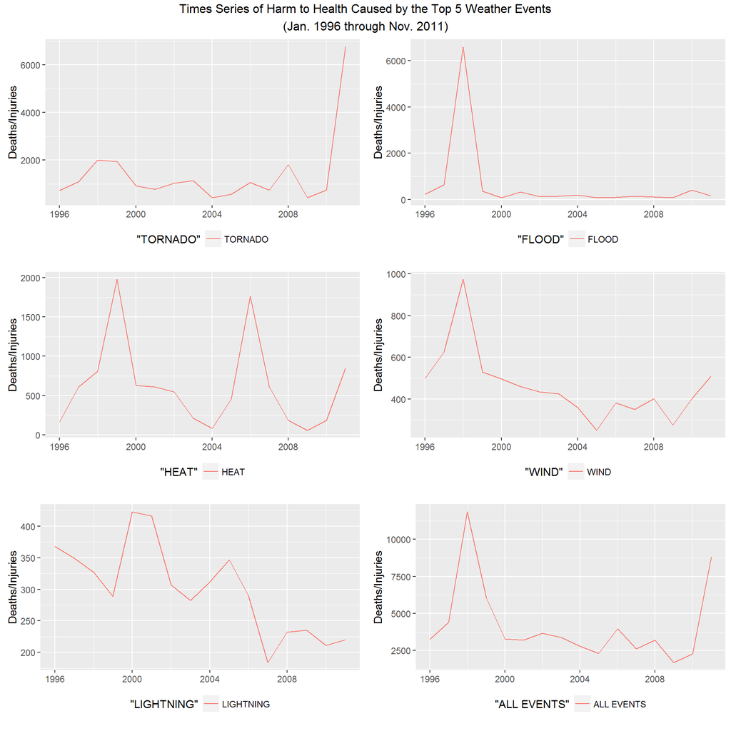

```r
grid.arrange(plotT1,plotF1,plotH1,plotW1,plotL1,plotA1,
 top= "Times Series of Harm to Health Caused by the Top 5 Weather Events\n(Jan. 1996 through Nov. 2011)")
```

In contrast to the previous panel the following panel shows that flood and hurricanes are the primary drivers with respect to impact on economic wellbeing. The “ALL EVENTS” graph shows that the economic impact of weather events has moderated in the most recent period, after the flood and hurricane driven spikes between 2004 and 2007; however, the recent increase in tornado activity is beginning to have an impact on costs. Still, in terms of orders of magnitude, flood and hurricane damage have been the main drivers of economic harm.

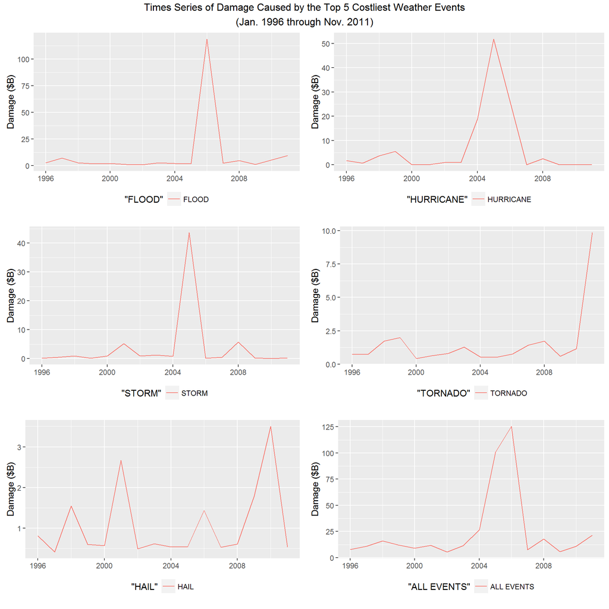

```r
grid.arrange(plotF,plotH,plotS,plotT,plotHa,plotA,
 top="Times Series of Damage Caused by the Top 5 Costliest Weather Events\n(Jan. 1996 through Nov. 2011)")
```

The final tables summarize the top 5 weather related public health events and the top 5 weather related economic events. Over the study, period flooding has been very harmful in terms of health, and the most costly in terms of economic wellbeing. However, the impact of flooding appears to be episodic with the largest harm to health occurring in 1998 and largest effect on economic cost occurring in 2006. By contrast, tornadoes appear to provide a consistent risk to public health and have become more damaging in terms of economic costs in the most recent year. That said, it would appear that flooding represents the more volatile, if not most consistent, threat to public health and economic wellbeing.

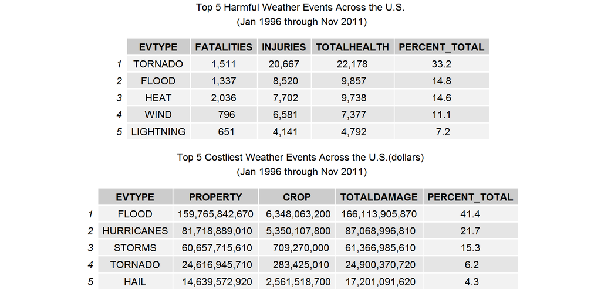

```r
grid.arrange(p1,p2, nrow=2)
```